# Red Wine Quality by Anav Gupta

### Density vs Quality

[figure not shown]

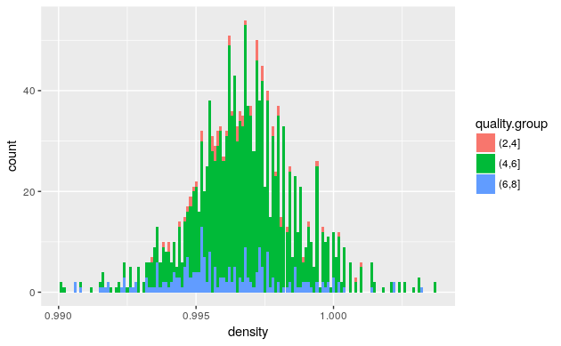

As we had already seen that the density of the wine varies over a narrow period. It’s difficult to find the trend between the density and the quality of a wine.

### Alcohol vs Quality

[figure not shown]

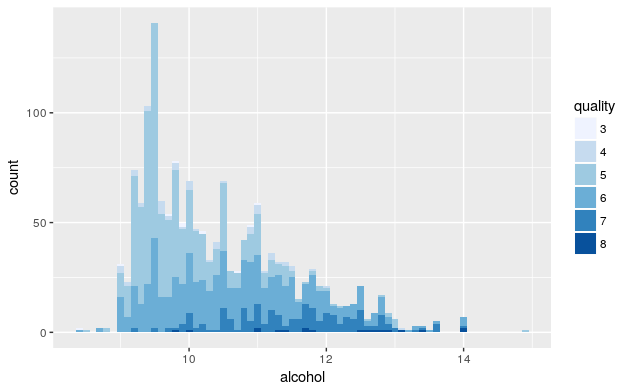

Now that we have tried to compare the physicochemical properties of wine with the quality of the wine. Now lets try to relate the physicochemical properties itself.

### Fixed Acidiy and Citric Acid

We know that the citric acid is a non-volatile acid and the fixed acidity tend to calculate the non-volatile acid content of the wine.

[figure not shown]

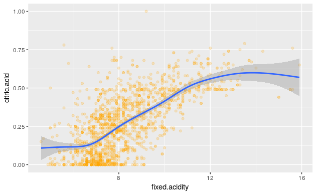

We do see some kind of correlation between the citric acid and the fixed acidity which was somewhat expected.

### Fixed Acidity and pH

[output not shown]

In the graph, it seems that the smooth line is going through the middle of the major portion of points.

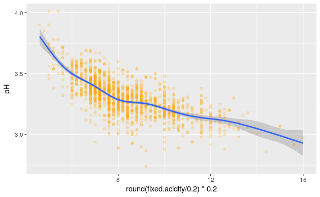

From above we can say that Fixed acidity and pH are negatively correlated. This seems plausible as well. As the acidic content of the wine increase, the pH value which gives the extent of the alkalinity/acidity should decrease. A substance with pH with value 0 is most acidic.

### Density and Fixed Acidity

[output not shown]

The data is dispersed in the upper half of the smooth line. I guess we do see some correlation. The smooth line somewhats affirm our belief.

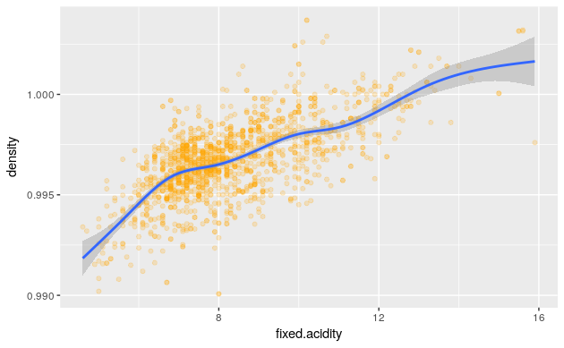

From the graph as well as from the R’s coefficient, we can say that density and fixed acidity are positively correlated.

### Free vs Total sulfur Dioxide

These are two variables that tell us about of concentration of the sulfur dioxide in the wine either free or fixed. So even from the definition of these two variables itself, we can postulate that these two variables must be correlated. Lets try out our postulation.

[output not shown]

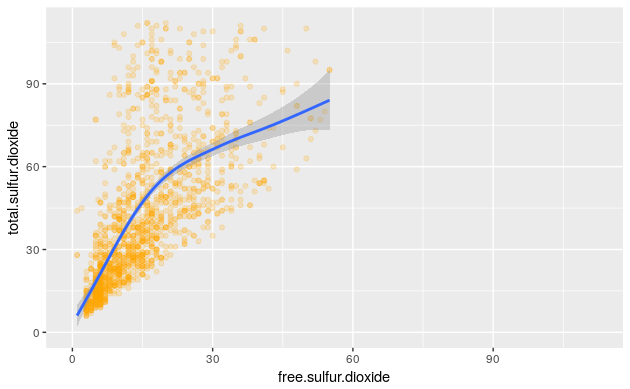

From the above analysis, it seems that they both are positively correlated.

```
    Pearson's product-moment correlation

data:  free.sulfur.dioxide and total.sulfur.dioxide
t = 35.84, df = 1597, p-value < 2.2e-16
alternative hypothesis: true correlation is not equal to 0
95 percent confidence interval:
 0.6395786 0.6939740
sample estimates:
      cor
0.6676665
```

### Density vs Alcohol

[output not shown]

```
    Pearson's product-moment correlation

data:  density and alcohol
t = -22.838, df = 1597, p-value < 2.2e-16
alternative hypothesis: true correlation is not equal to 0
95 percent confidence interval:
 -0.5322547 -0.4583061
sample estimates:
       cor
-0.4961798
```

We can see that there is about negative correlation among the density and alcohol. The smooth line does passes through most of important places.

# Bivariate Analysis

This section lists the analysis of the bi-variate explorations.

### Talk about some of the relationships you observed in this part of the investigation. How did the feature(s) of interest vary with other features in the dataset?

The alcohol content in the wine correlates with the quality of the wine. With the increase in the quality of the wine, the average (mean and median) of the wine’s alcohol content increases.

The Volatile Acidity correlates mildly correlates (Negatively) with the quality of the wine.

With the increase in the quality of the wine, the median as well as the mean quantity of the volatile acidity decreases.

The content of citric acid (mean as well as median) increases with the increase in the quality of the wine.

The median as well as the mean of quantity of the sulphate increases with the increase in the quality of the wine.

There doesn’t seem to be any kind of relation between residual sugar and the quality of the wine, but it must be noted that for more than 50 percent of time, the residual sugar was within 2-3 units.

### Did you observe any interesting relationships between the other features (not the main feature(s) of interest)?

Fixed acidity and Citric acid tends to correlate with each other. Since Citric acid is also a non-volatile acid, the fixed acidity gives the total non-volatile acid content, this relationship makes sense.

Fixed Acidity and pH are negatively correlated to each other. If the fixed acidity of the wine will increase, it’s pH value will decrease. This makes sense as with more non-volatile acid in the wine, it’s acidity will increase and hence it’s pH will decrease. Solution with 0 pH value is a most acidic substance.

Density and Fixed Acidity tend to correlate with each other (mildly). If we increase the fixed acidity of the wine, the density of the wine tend to increase.

# Multivariate Plots Section

In this section we will try to examine multiple variable at a time.

### Density vs Fixed Acidity by Quality

[figure not shown]

It looks like that the normal group tend to follow the smooth line roughly. We can see major variations in the better group, but all in all they somehow follow the smooth line. Gives us indications that density and fixed acidity are in fact correlated.

### Citric Acid vs Fixed Acidity by Quality

[figure not shown]

We can see that the worst group seems to vary a lot over the course. Albeit, If we look at the normal and better groups we can see that the median for these groups tend to follow the geom smooth line.

### Fixed Acidity vs pH by Quality

[figure not shown]

### Density vs Alcohol by Quality

[figure not shown]

We can see that there are a lot of variations in all groups of wine.

### Free sulfur dioxide vs Total Sulfur Dioxide by Quality

[figure not shown]

We can see that for lower values of total sulfur dioxide there is very less amount of variance in the value of free sulfur dioxide. As the total sulfur dioxide starts to increase the variation in the amount of free sulfur dioxide. With the help of quality group we can see there is very frequent change for the wines in the normal category. The change is not that frequent in other group of wines.

### Linear model for density

Here we will create linear model with density, alcohol and fixed acidity.

[figure not shown]

Sp it turns out that 65 percent of variance in density is explained by alcohol content and the fixed acidity of the wine.

### Quality Linear Model

Now lets try to make a linear model for the quality of the wine.

One to check before making the linear model is that the variables in the model should not be correlated with each other. This can create ambiguity in deciding which component is responsible for the change in model.

- Alcohol
- pH
- Sulphates
- residual.sugar
- Fixed Acidity
- Chlorides
- Total Sulfur Dioxide

[output not shown]

A model that tries to explain the variation in the quality of the wine. We get a r-squared value of 0.3142.

# Multivariate Analysis

### Talk about some of the relationships you observed in this part of the investigation. Were there features that strengthened each other in terms of looking at your feature(s) of interest?

There seems to be a strong relationship between Density and the Alcohol and the fixed acidity.

### Were there any interesting or surprising interactions between features?

There is a surprising interaction between Density and the combination of alcohol and fixed acidity. It may have to do something with the chemistry of the fluids, but nonetheless it is an interesting relation that one find without the innate knowledge of the chemistry behind this interactions.

### OPTIONAL: Did you create any models with your dataset? Discuss the strengths and limitations of your model.

Albeit, their combination seems to explain only 31 percent of variance in the quality of the wines.

# Final Plots and Summary

### Plot One

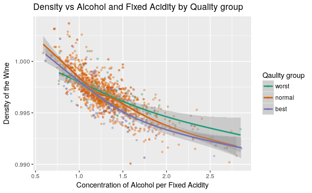

[output not shown]

### Plot Two

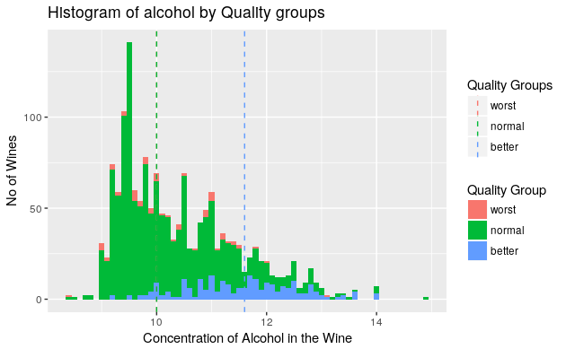

### Plot Three

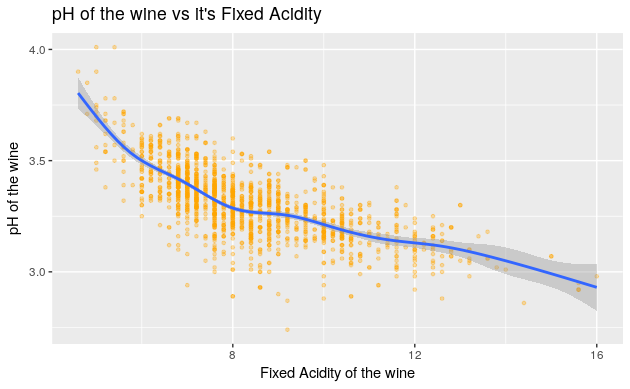

### Description Three

We all know that ph and acid content have a relation among each other. we are taught this in middle school. A liquid is consumable only at particular level of acidity. This graph help us showcase that innate relation between pH value of the wine and it’s Fixed Acidity. With enough correlation, we can say that the wine data do states the same relation among ph and acidity as it would have been normally accepted.

# Reflection

Red Wine data set contained 11 physicochemical variables. I have explored all the variable against the output i.e the quality of the wine. While some variables like, alcohol, sulphates tend to have a effect on the quality of the wine, some didn’t.

From the exploration it seems that wines with more alcohol content tend to have higher quality. Same goes with the sulphates as well.

The relationship between the density of the wine and the Alcohol concentration plus the fixed acidity comes to me as a surprise. It wasn’t expected. This is what you get when you explore the data. For a chemist this may seems like a predefined relation, but for a guy with very limited knowledge with the chemistry of fluids this relation is a revelation.

The main problem that I face is that, we have limited amount of data. The fact we have only 10, 52 and only 18 wines with qualities 3, 4 and 8, is a sense of concern. Limited data does not help.

While I have explored the data set to my fullest abilities, I still feel that we could explore the data even further by taking complex combinations of alcohol and sulphates at a time. These two variable have shown to have stronger correlation with quality of the wine that any other variables.

This exploration will be of very menial value if we can’t increase the data available for the lower qualities as well as higher qualities of wine. To understand what parameters really make the wine bad or good, we will need to access more data.